# Estimation du risque avec caret

On cherche à expliquer une variable binaire $Y$ par deux variables quantitatives $X_1$ et $X_2$ à l’aide du jeu de données suivant

```r
n <- 2000
set.seed(12345)
X1 <- runif(n)
set.seed(5678)
X2 <- runif(n)
set.seed(9012)
R1 <- X1<=0.25
R2 <- (X1>0.25 & X2>=0.75)
R3 <- (X1>0.25 & X2<0.75)
Y <- rep(0,n)
Y[R1] <- rbinom(sum(R1),1,0.25)
Y[R2] <- rbinom(sum(R2),1,0.25)
Y[R3] <- rbinom(sum(R3),1,0.75)
donnees <- data.frame(X1,X2,Y)
donnees$Y <- as.factor(donnees$Y)
```

1. Séparer le jeu de données en un échantillon d’apprentissage de taille 1500 et un échantillon test de taille 500.

```r
indapp <- 1:1500
dapp <- donnees[indapp,]
dtest <- donnees[-indapp,]
```

2. On considère la régle de classification des $k$ plus proches voisins. Pour un entier $k$ plus petit que $n$ et un nouvel individu $x$, cette règle affecte à $x$ le label majoritaire des $k$ plus proches voisins de $x$. Sur **R** on utilise la fonction **knn** du package **class**. On peut par exemple obtenir les prévisions des individus de l’échantillon test de la règle des 3 plus proches voisins avec

```r
library(class)
knn3 <- knn(dapp[,1:2],dtest[,1:2],cl=dapp$Y,k=3)
head(knn3)
```

```
## [1] 1 1 1 0 0 1
## Levels: 0 1
```

Calculer l’erreur de classification de la règle des 3 plus proches voisins sur les données test.

```r
mean(knn3!=dtest$Y)
```

```
## [1] 0.308
```

3. Expliquer la fonction **knn.cv**

On prédit le groupe de chaque individu par **validation croisée leave-one-out** :

$$\widehat y_i=g_{k,i}(x_i),\quad i=1,\dots,n$$

où $g_{k,i}$ désigne la règle de $k$ plus proche voisins construites à partir de l’échantillon amputé de la $i$ème observation.

4. Calculer l’erreur de classification de la règle des 3 plus proches voisins par validation croisée **leave-one-out**.

```r
prev_cv <- knn.cv(donnees[,-3],cl=donnees$Y,k=3)
```

```r
mean(prev_cv!=donnees$Y)
```

```
## [1] 0.319
```

5. On considère le vecteur de plus proches voisins suivant :

```r
K_cand <- seq(1,500,by=20)
```

Proposer 2 façons de choisir une valeur de $k$ dans ce vecteur.

- On calcule l’erreur de classification par **validation hold** out pour chaque valeur de $k$ :

```r
err.ho <- rep(0,length(K_cand))
for (i in 1:length(K_cand)){
  knni <- knn(dapp[,1:2],dtest[,1:2],cl=dapp$Y,k=K_cand[i])
  err.ho[i] <- mean(knni!=dtest$Y)
}
```

Puis on choisir la valeur de $k$ pour laquelle l’erreur est minimale.

```r
K_cand[which.min(err.ho)]
```

```
## [1] 41
```

- On fait la même chose avec la **validation croisée leave-one-out** :

```r
err.cv <- rep(0,length(K_cand))
for (i in 1:length(K_cand)){
  knni <- knn.cv(donnees[,-3],cl=donnees$Y,k=K_cand[i])
  err.cv[i] <- mean(knni!=donnees$Y)
}
K_cand[which.min(err.cv)]
```

```
## [1] 41
```

On souhaite maintenant utiliser le package **caret** pour estimer des critères d’erreur et sélectionner des paramètres. On garde le même cadre que précédemment où on cherche à sélectionner le paramètre $k$ de la règle des plus proches voisins. On pourra consulter l’url http://topepo.github.io/caret/index.html

6. Expliquer les sorties des commandes

```r
library(caret)
ctrl1 <- trainControl(method="LGOCV",number=1,index=list(1:1500))
KK <- data.frame(k=K_cand)
ee1 <- train(Y~.,data=donnees,method="knn",trControl=ctrl1,tuneGrid=KK)
ee1
```

```
## k-Nearest Neighbors
##
## 2000 samples
##    2 predictor
##    2 classes: '0', '1'
##
## No pre-processing
## Resampling: Repeated Train/Test Splits Estimated (1 reps, 75%)
## Summary of sample sizes: 1500
## Resampling results across tuning parameters:
##
##   k    Accuracy  Kappa
##     1  0.620     0.2298338
##    21  0.772     0.5349141
##    41  0.778     0.5459306
```

[output cut: 25 more lines]

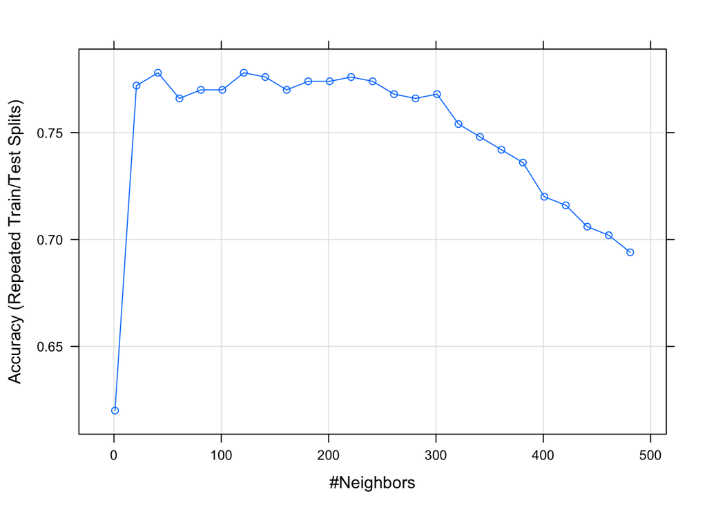

```r
plot(ee1)
```

La probabilité d’erreur est estimée par validation hold out (même résultat que **err.ho**).

7. Utiliser **caret** pour sélectionner $k$ par validation croisée leave-one-out.

```r
ctrl2 <- trainControl(method="LOOCV",number=1)
ee2 <- train(Y~.,data=donnees,method="knn",trControl=ctrl2,tuneGrid=KK)
ee2
```

```
## k-Nearest Neighbors
##
## 2000 samples
##    2 predictor
##    2 classes: '0', '1'
##
## No pre-processing
## Resampling: Leave-One-Out Cross-Validation
## Summary of sample sizes: 1999, 1999, 1999, 1999, 1999, 1999, ...
## Resampling results across tuning parameters:
##
##   k    Accuracy  Kappa
##     1  0.6230    0.2375953
##    21  0.7305    0.4503096
##    41  0.7360    0.4610133
```

[output cut: 25 more lines]

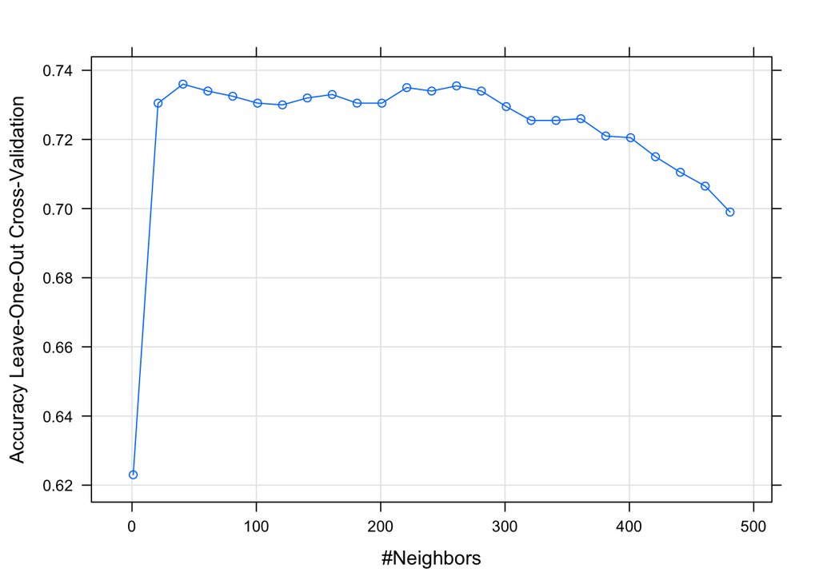

```r
plot(ee2)
```

8. Faire de même pour la validation croisée 10 blocs.

```r
ctrl3 <- trainControl(method="cv",number=10)
ee3 <- train(Y~.,data=donnees,method="knn",trControl=ctrl3,tuneGrid=KK)
ee3
```

```
## k-Nearest Neighbors
##
## 2000 samples
##    2 predictor
##    2 classes: '0', '1'
##
## No pre-processing
## Resampling: Cross-Validated (10 fold)
## Summary of sample sizes: 1800, 1799, 1799, 1801, 1800, 1801, ...
## Resampling results across tuning parameters:
##
##   k    Accuracy   Kappa
##     1  0.6239518  0.2385112
##    21  0.7294508  0.4479972
##    41  0.7344509  0.4576559
```

[output cut: 25 more lines]

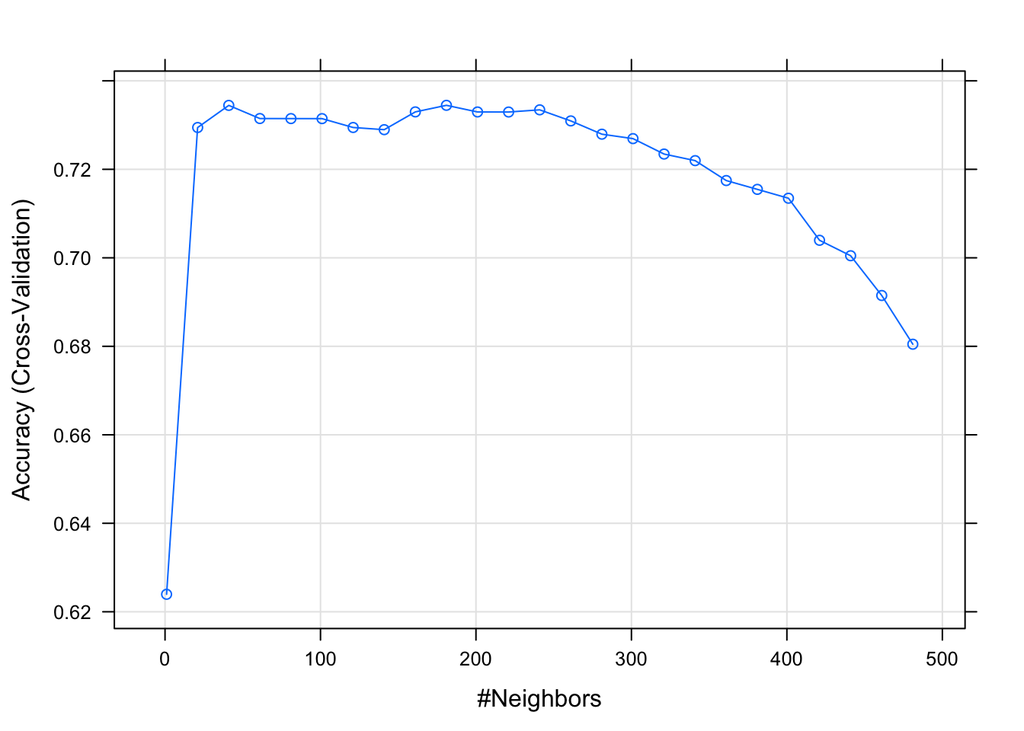

```r
plot(ee3)
```

Les validations croisés peuvent se révéler couteuses en temps de calcul. On utlise souvent des techniques de parallélisation pour améliorer les performances computationnelles. Ces techniques sont relativement facile à mettre en oeuvre avec **caret**, on peut par exemple utiliser la librairie **doParallel** :

```r
library(doParallel)
cl <- makePSOCKcluster(1)
registerDoParallel(cl)
system.time(ee3 <- train(Y~.,data=donnees,method="knn",trControl=ctrl3,tuneGrid=KK))
```

```
##    user  system elapsed
##  12.405   0.013  12.426
```

```r
stopCluster(cl)
cl <- makePSOCKcluster(4)
registerDoParallel(cl)
system.time(ee3 <- train(Y~.,data=donnees,method="knn",trControl=ctrl3,tuneGrid=KK))
```

```
##    user  system elapsed
##   0.570   0.014   5.752
```

```r
stopCluster(cl)
```